# Risk Factor Analysis

## Outcome Variable

**Outcome Variable:** ever_stunted

## Predictor Variables

**Intervention Variable:** anywast06

**Adjustment Set:**

unadjusted

## Stratifying Variables

The analysis was stratified on these variable(s):

- agecat
- studyid
- country

## Data Summary

| agecat | studyid | country | anywast06 | ever_stunted | n_cell | n |
| --- | --- | --- | --- | --- | --- | --- |
| 0-6 months | ki0047075b-MAL-ED | BANGLADESH | 0 | 0 | 168 | 263 |
| 0-6 months | ki0047075b-MAL-ED | BANGLADESH | 0 | 1 | 36 | 263 |
| 0-6 months | ki0047075b-MAL-ED | BANGLADESH | 1 | 0 | 49 | 263 |
| 0-6 months | ki0047075b-MAL-ED | BANGLADESH | 1 | 1 | 10 | 263 |
| 0-6 months | ki0047075b-MAL-ED | BRAZIL | 0 | 0 | 194 | 233 |
| 0-6 months | ki0047075b-MAL-ED | BRAZIL | 0 | 1 | 25 | 233 |
| 0-6 months | ki0047075b-MAL-ED | BRAZIL | 1 | 0 | 14 | 233 |
| 0-6 months | ki0047075b-MAL-ED | BRAZIL | 1 | 1 | 0 | 233 |
| 0-6 months | ki0047075b-MAL-ED | INDIA | 0 | 0 | 144 | 251 |
| 0-6 months | ki0047075b-MAL-ED | INDIA | 0 | 1 | 28 | 251 |
| 0-6 months | ki0047075b-MAL-ED | INDIA | 1 | 0 | 65 | 251 |
| 0-6 months | ki0047075b-MAL-ED | INDIA | 1 | 1 | 14 | 251 |
| 0-6 months | ki0047075b-MAL-ED | NEPAL | 0 | 0 | 177 | 240 |
| 0-6 months | ki0047075b-MAL-ED | NEPAL | 0 | 1 | 19 | 240 |
| 0-6 months | ki0047075b-MAL-ED | NEPAL | 1 | 0 | 35 | 240 |
| 0-6 months | ki0047075b-MAL-ED | NEPAL | 1 | 1 | 9 | 240 |
| 0-6 months | ki0047075b-MAL-ED | PERU | 0 | 0 | 258 | 302 |
| 0-6 months | ki0047075b-MAL-ED | PERU | 0 | 1 | 33 | 302 |
| 0-6 months | ki0047075b-MAL-ED | PERU | 1 | 0 | 8 | 302 |
| 0-6 months | ki0047075b-MAL-ED | PERU | 1 | 1 | 3 | 302 |
| 0-6 months | ki0047075b-MAL-ED | SOUTH AFRICA | 0 | 0 | 251 | 313 |
| 0-6 months | ki0047075b-MAL-ED | SOUTH AFRICA | 0 | 1 | 27 | 313 |
| 0-6 months | ki0047075b-MAL-ED | SOUTH AFRICA | 1 | 0 | 29 | 313 |
| 0-6 months | ki0047075b-MAL-ED | SOUTH AFRICA | 1 | 1 | 6 | 313 |
| 0-6 months | ki0047075b-MAL-ED | TANZANIA, UNITED REPUBLIC OF | 0 | 0 | 210 | 261 |
| 0-6 months | ki0047075b-MAL-ED | TANZANIA, UNITED REPUBLIC OF | 0 | 1 | 40 | 261 |
| 0-6 months | ki0047075b-MAL-ED | TANZANIA, UNITED REPUBLIC OF | 1 | 0 | 9 | 261 |
| 0-6 months | ki0047075b-MAL-ED | TANZANIA, UNITED REPUBLIC OF | 1 | 1 | 2 | 261 |
| 0-6 months | ki1000108-CMC-V-BCS-2002 | INDIA | 0 | 0 | 137 | 368 |
| 0-6 months | ki1000108-CMC-V-BCS-2002 | INDIA | 0 | 1 | 37 | 368 |

[output cut: 198 more lines]

The following strata were considered:

- agecat: 0-24 months, studyid: ki0047075b-MAL-ED, country: BANGLADESH
- agecat: 0-24 months, studyid: ki0047075b-MAL-ED, country: BRAZIL
- agecat: 0-24 months, studyid: ki0047075b-MAL-ED, country: INDIA
- agecat: 0-24 months, studyid: ki0047075b-MAL-ED, country: NEPAL
- agecat: 0-24 months, studyid: ki0047075b-MAL-ED, country: PERU
- agecat: 0-24 months, studyid: ki0047075b-MAL-ED, country: SOUTH AFRICA
- agecat: 0-24 months, studyid: ki0047075b-MAL-ED, country: TANZANIA, UNITED REPUBLIC OF
- agecat: 0-24 months, studyid: ki1000108-CMC-V-BCS-2002, country: INDIA
- agecat: 0-24 months, studyid: ki1000108-IRC, country: INDIA
- agecat: 0-24 months, studyid: ki1000109-EE, country: PAKISTAN
- agecat: 0-24 months, studyid: ki1000109-ResPak, country: PAKISTAN
- agecat: 0-24 months, studyid: ki1017093b-PROVIDE, country: BANGLADESH
- agecat: 0-24 months, studyid: ki1066203-TanzaniaChild2, country: TANZANIA, UNITED REPUBLIC OF
- agecat: 0-24 months, studyid: ki1101329-Keneba, country: GAMBIA
- agecat: 0-24 months, studyid: ki1112895-Guatemala BSC, country: GUATEMALA
- agecat: 0-24 months, studyid: ki1113344-GMS-Nepal, country: NEPAL
- agecat: 0-24 months, studyid: ki1114097-CMIN, country: BANGLADESH
- agecat: 0-24 months, studyid: ki1114097-CMIN, country: PERU
- agecat: 0-24 months, studyid: ki1114097-CONTENT, country: PERU
- agecat: 0-6 months, studyid: ki0047075b-MAL-ED, country: BANGLADESH
- agecat: 0-6 months, studyid: ki0047075b-MAL-ED, country: BRAZIL
- agecat: 0-6 months, studyid: ki0047075b-MAL-ED, country: INDIA
- agecat: 0-6 months, studyid: ki0047075b-MAL-ED, country: NEPAL
- agecat: 0-6 months, studyid: ki0047075b-MAL-ED, country: PERU
- agecat: 0-6 months, studyid: ki0047075b-MAL-ED, country: SOUTH AFRICA
- agecat: 0-6 months, studyid: ki0047075b-MAL-ED, country: TANZANIA, UNITED REPUBLIC OF
- agecat: 0-6 months, studyid: ki1000108-CMC-V-BCS-2002, country: INDIA
- agecat: 0-6 months, studyid: ki1000108-IRC, country: INDIA
- agecat: 0-6 months, studyid: ki1000109-EE, country: PAKISTAN
- agecat: 0-6 months, studyid: ki1000109-ResPak, country: PAKISTAN
- agecat: 0-6 months, studyid: ki1017093b-PROVIDE, country: BANGLADESH
- agecat: 0-6 months, studyid: ki1066203-TanzaniaChild2, country: TANZANIA, UNITED REPUBLIC OF
- agecat: 0-6 months, studyid: ki1101329-Keneba, country: GAMBIA
- agecat: 0-6 months, studyid: ki1112895-Guatemala BSC, country: GUATEMALA
- agecat: 0-6 months, studyid: ki1113344-GMS-Nepal, country: NEPAL
- agecat: 0-6 months, studyid: ki1114097-CMIN, country: BANGLADESH
- agecat: 0-6 months, studyid: ki1114097-CMIN, country: PERU
- agecat: 0-6 months, studyid: ki1114097-CONTENT, country: PERU
- agecat: 6-24 months, studyid: ki0047075b-MAL-ED, country: BANGLADESH
- agecat: 6-24 months, studyid: ki0047075b-MAL-ED, country: BRAZIL
- agecat: 6-24 months, studyid: ki0047075b-MAL-ED, country: INDIA
- agecat: 6-24 months, studyid: ki0047075b-MAL-ED, country: NEPAL
- agecat: 6-24 months, studyid: ki0047075b-MAL-ED, country: PERU
- agecat: 6-24 months, studyid: ki0047075b-MAL-ED, country: SOUTH AFRICA
- agecat: 6-24 months, studyid: ki0047075b-MAL-ED, country: TANZANIA, UNITED REPUBLIC OF
- agecat: 6-24 months, studyid: ki1000108-CMC-V-BCS-2002, country: INDIA
- agecat: 6-24 months, studyid: ki1000108-IRC, country: INDIA
- agecat: 6-24 months, studyid: ki1000109-EE, country: PAKISTAN
- agecat: 6-24 months, studyid: ki1000109-ResPak, country: PAKISTAN
- agecat: 6-24 months, studyid: ki1017093b-PROVIDE, country: BANGLADESH
- agecat: 6-24 months, studyid: ki1066203-TanzaniaChild2, country: TANZANIA, UNITED REPUBLIC OF
- agecat: 6-24 months, studyid: ki1101329-Keneba, country: GAMBIA
- agecat: 6-24 months, studyid: ki1112895-Guatemala BSC, country: GUATEMALA
- agecat: 6-24 months, studyid: ki1113344-GMS-Nepal, country: NEPAL
- agecat: 6-24 months, studyid: ki1114097-CMIN, country: BANGLADESH
- agecat: 6-24 months, studyid: ki1114097-CMIN, country: PERU
- agecat: 6-24 months, studyid: ki1114097-CONTENT, country: PERU

### Dropped Strata

Some strata were dropped due to rare outcomes:

- agecat: 0-6 months, studyid: ki0047075b-MAL-ED, country: BRAZIL
- agecat: 0-6 months, studyid: ki0047075b-MAL-ED, country: PERU
- agecat: 0-6 months, studyid: ki0047075b-MAL-ED, country: TANZANIA, UNITED REPUBLIC OF
- agecat: 0-6 months, studyid: ki1112895-Guatemala BSC, country: GUATEMALA
- agecat: 0-6 months, studyid: ki1114097-CONTENT, country: PERU
- agecat: 6-24 months, studyid: ki0047075b-MAL-ED, country: BRAZIL
- agecat: 6-24 months, studyid: ki0047075b-MAL-ED, country: PERU
- agecat: 6-24 months, studyid: ki0047075b-MAL-ED, country: TANZANIA, UNITED REPUBLIC OF
- agecat: 6-24 months, studyid: ki1112895-Guatemala BSC, country: GUATEMALA
- agecat: 6-24 months, studyid: ki1114097-CONTENT, country: PERU
- agecat: 0-24 months, studyid: ki0047075b-MAL-ED, country: BRAZIL
- agecat: 0-24 months, studyid: ki0047075b-MAL-ED, country: PERU
- agecat: 0-24 months, studyid: ki0047075b-MAL-ED, country: TANZANIA, UNITED REPUBLIC OF
- agecat: 0-24 months, studyid: ki1112895-Guatemala BSC, country: GUATEMALA
- agecat: 0-24 months, studyid: ki1114097-CONTENT, country: PERU

## Methods Detail

We’re interested in the causal parameters $E[Y_a]$ for all values of $a \in \mathcal{A}$. These parameters represent the mean outcome if, possibly contrary to fact, we intervened to set all units to have $A=a$. Under the randomization and positivity assumptions, these are identified by the statistical parameters $\psi_a=E_W[E_{Y|A,W}(Y|A=a,W)]$. In addition, we’re interested in the mean of $Y$, $E[Y]$ under no intervention (the observed mean). We will estimate these parameters by using SuperLearner to fit the relevant likelihood factors – $E_{Y|A,W}(Y|A=a,W)$ and $p(A=a|W)$, and then updating our likelihood fit using a joint TMLE.

For unadjusted analyses ($W=\{\}$), initial likelihoods were estimated using Lrnr_glm to estimate the simple $E(Y|A)$ and Lrnr_mean to estimate $p(A)$. For adjusted analyses, a small library containing Lrnr_glmnet, Lrnr_xgboost, and Lrnr_mean was used.

Having estimated these parameters, we will then use the delta method to estimate relative risks and attributable risks relative to a prespecified baseline level of $A$.

# Results Detail

## Results Plots

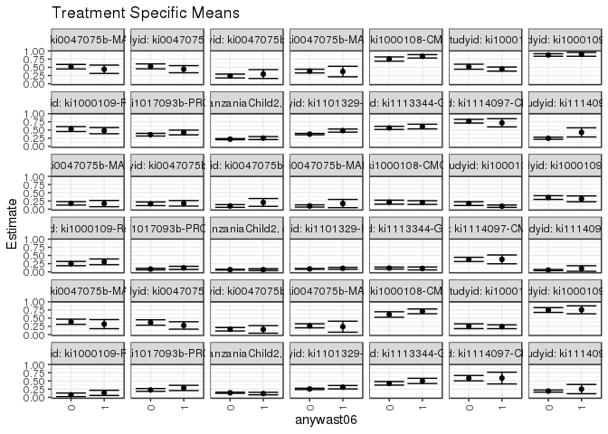

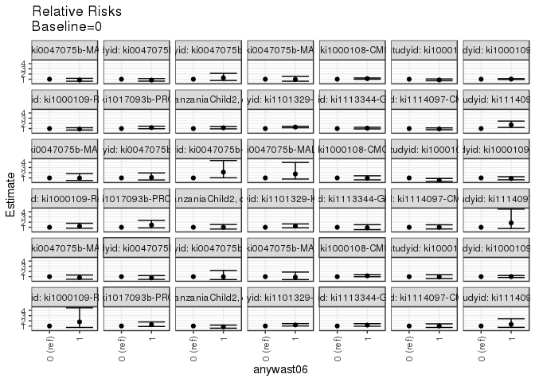

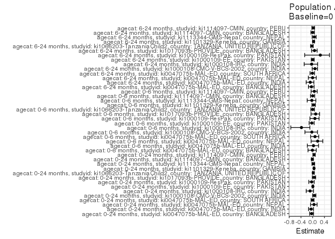

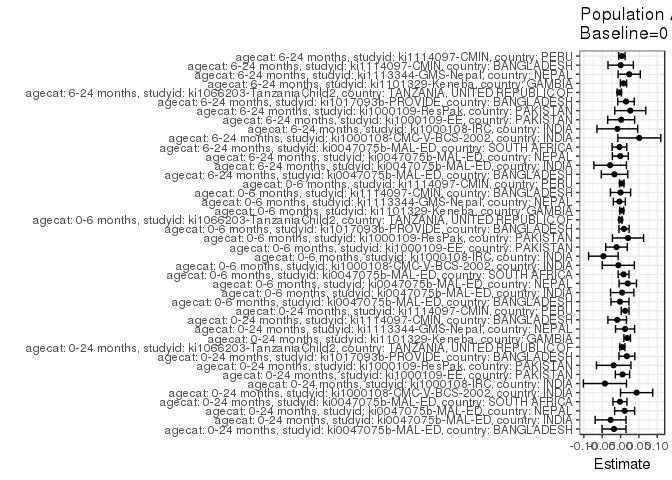

## Results Table

### Parameter: TSM

| agecat | studyid | country | intervention_level | baseline_level | estimate | ci_lower | ci_upper |
| --- | --- | --- | --- | --- | --- | --- | --- |
| 0-24 months | ki0047075b-MAL-ED | BANGLADESH | 0 | NA | 0.5196078 | 0.4509174 | 0.5882982 |
| 0-24 months | ki0047075b-MAL-ED | BANGLADESH | 1 | NA | 0.4406780 | 0.3137548 | 0.5676011 |
| 0-24 months | ki0047075b-MAL-ED | INDIA | 0 | NA | 0.5290698 | 0.4543242 | 0.6038153 |
| 0-24 months | ki0047075b-MAL-ED | INDIA | 1 | NA | 0.4430380 | 0.3332804 | 0.5527956 |
| 0-24 months | ki0047075b-MAL-ED | NEPAL | 0 | NA | 0.2346939 | 0.1752379 | 0.2941498 |
| 0-24 months | ki0047075b-MAL-ED | NEPAL | 1 | NA | 0.2954545 | 0.1603630 | 0.4305461 |
| 0-24 months | ki0047075b-MAL-ED | SOUTH AFRICA | 0 | NA | 0.3848921 | 0.3276038 | 0.4421804 |
| 0-24 months | ki0047075b-MAL-ED | SOUTH AFRICA | 1 | NA | 0.3714286 | 0.2110952 | 0.5317619 |
| 0-24 months | ki1000108-CMC-V-BCS-2002 | INDIA | 0 | NA | 0.7528736 | 0.6886960 | 0.8170511 |
| 0-24 months | ki1000108-CMC-V-BCS-2002 | INDIA | 1 | NA | 0.8358974 | 0.7838434 | 0.8879515 |
| 0-24 months | ki1000108-IRC | INDIA | 0 | NA | 0.5180723 | 0.4419678 | 0.5941768 |
| 0-24 months | ki1000108-IRC | INDIA | 1 | NA | 0.4467213 | 0.3842654 | 0.5091773 |
| 0-24 months | ki1000109-EE | PAKISTAN | 0 | NA | 0.8759124 | 0.8368246 | 0.9150002 |
| 0-24 months | ki1000109-EE | PAKISTAN | 1 | NA | 0.8952381 | 0.8365840 | 0.9538922 |
| 0-24 months | ki1000109-ResPak | PAKISTAN | 0 | NA | 0.5294118 | 0.4542454 | 0.6045781 |
| 0-24 months | ki1000109-ResPak | PAKISTAN | 1 | NA | 0.4814815 | 0.3870774 | 0.5758855 |
| 0-24 months | ki1017093b-PROVIDE | BANGLADESH | 0 | NA | 0.3583815 | 0.3170971 | 0.3996659 |
| 0-24 months | ki1017093b-PROVIDE | BANGLADESH | 1 | NA | 0.4254144 | 0.3533364 | 0.4974924 |
| 0-24 months | ki1066203-TanzaniaChild2 | TANZANIA, UNITED REPUBLIC OF | 0 | NA | 0.2210321 | 0.2030837 | 0.2389805 |
| 0-24 months | ki1066203-TanzaniaChild2 | TANZANIA, UNITED REPUBLIC OF | 1 | NA | 0.2543860 | 0.2082192 | 0.3005527 |
| 0-24 months | ki1101329-Keneba | GAMBIA | 0 | NA | 0.3747563 | 0.3538081 | 0.3957045 |
| 0-24 months | ki1101329-Keneba | GAMBIA | 1 | NA | 0.4830097 | 0.4347475 | 0.5312719 |
| 0-24 months | ki1113344-GMS-Nepal | NEPAL | 0 | NA | 0.5656325 | 0.5181320 | 0.6131329 |
| 0-24 months | ki1113344-GMS-Nepal | NEPAL | 1 | NA | 0.6065574 | 0.5357204 | 0.6773944 |
| 0-24 months | ki1114097-CMIN | BANGLADESH | 0 | NA | 0.7692308 | 0.7135799 | 0.8248816 |
| 0-24 months | ki1114097-CMIN | BANGLADESH | 1 | NA | 0.7200000 | 0.5953159 | 0.8446841 |
| 0-24 months | ki1114097-CMIN | PERU | 0 | NA | 0.2492308 | 0.2159528 | 0.2825087 |
| 0-24 months | ki1114097-CMIN | PERU | 1 | NA | 0.4285714 | 0.2899107 | 0.5672322 |
| 0-6 months | ki0047075b-MAL-ED | BANGLADESH | 0 | NA | 0.1764706 | 0.1240580 | 0.2288832 |
| 0-6 months | ki0047075b-MAL-ED | BANGLADESH | 1 | NA | 0.1694915 | 0.0735746 | 0.2654085 |

[output cut: 54 more lines]

### Parameter: E(Y)

| agecat | studyid | country | intervention_level | baseline_level | estimate | ci_lower | ci_upper |
| --- | --- | --- | --- | --- | --- | --- | --- |
| 0-24 months | ki0047075b-MAL-ED | BANGLADESH | NA | NA | 0.5019011 | 0.4413581 | 0.5624442 |
| 0-24 months | ki0047075b-MAL-ED | INDIA | NA | NA | 0.5019920 | 0.4400130 | 0.5639710 |
| 0-24 months | ki0047075b-MAL-ED | NEPAL | NA | NA | 0.2458333 | 0.1912446 | 0.3004221 |
| 0-24 months | ki0047075b-MAL-ED | SOUTH AFRICA | NA | NA | 0.3833866 | 0.3294360 | 0.4373371 |
| 0-24 months | ki1000108-CMC-V-BCS-2002 | INDIA | NA | NA | 0.7967480 | 0.7556328 | 0.8378631 |
| 0-24 months | ki1000108-IRC | INDIA | NA | NA | 0.4756098 | 0.4272105 | 0.5240091 |
| 0-24 months | ki1000109-EE | PAKISTAN | NA | NA | 0.8812665 | 0.8486571 | 0.9138759 |
| 0-24 months | ki1000109-ResPak | PAKISTAN | NA | NA | 0.5107914 | 0.4519237 | 0.5696591 |
| 0-24 months | ki1017093b-PROVIDE | BANGLADESH | NA | NA | 0.3757143 | 0.3398113 | 0.4116172 |
| 0-24 months | ki1066203-TanzaniaChild2 | TANZANIA, UNITED REPUBLIC OF | NA | NA | 0.2257930 | 0.2090482 | 0.2425378 |
| 0-24 months | ki1101329-Keneba | GAMBIA | NA | NA | 0.3928571 | 0.3735695 | 0.4121448 |
| 0-24 months | ki1113344-GMS-Nepal | NEPAL | NA | NA | 0.5780731 | 0.5385891 | 0.6175571 |
| 0-24 months | ki1114097-CMIN | BANGLADESH | NA | NA | 0.7601476 | 0.7092160 | 0.8110792 |
| 0-24 months | ki1114097-CMIN | PERU | NA | NA | 0.2618026 | 0.2291894 | 0.2944158 |
| 0-6 months | ki0047075b-MAL-ED | BANGLADESH | NA | NA | 0.1749049 | 0.1289057 | 0.2209042 |
| 0-6 months | ki0047075b-MAL-ED | INDIA | NA | NA | 0.1673307 | 0.1210604 | 0.2136010 |
| 0-6 months | ki0047075b-MAL-ED | NEPAL | NA | NA | 0.1166667 | 0.0759676 | 0.1573658 |
| 0-6 months | ki0047075b-MAL-ED | SOUTH AFRICA | NA | NA | 0.1054313 | 0.0713542 | 0.1395084 |
| 0-6 months | ki1000108-CMC-V-BCS-2002 | INDIA | NA | NA | 0.2065217 | 0.1651060 | 0.2479375 |
| 0-6 months | ki1000108-IRC | INDIA | NA | NA | 0.1219512 | 0.0902381 | 0.1536643 |
| 0-6 months | ki1000109-EE | PAKISTAN | NA | NA | 0.3430079 | 0.2951521 | 0.3908637 |
| 0-6 months | ki1000109-ResPak | PAKISTAN | NA | NA | 0.2733813 | 0.2208950 | 0.3258676 |
| 0-6 months | ki1017093b-PROVIDE | BANGLADESH | NA | NA | 0.0942857 | 0.0726222 | 0.1159492 |
| 0-6 months | ki1066203-TanzaniaChild2 | TANZANIA, UNITED REPUBLIC OF | NA | NA | 0.0671953 | 0.0571686 | 0.0772221 |
| 0-6 months | ki1101329-Keneba | GAMBIA | NA | NA | 0.0933442 | 0.0818552 | 0.1048331 |
| 0-6 months | ki1113344-GMS-Nepal | NEPAL | NA | NA | 0.1112957 | 0.0861520 | 0.1364394 |
| 0-6 months | ki1114097-CMIN | BANGLADESH | NA | NA | 0.3800738 | 0.3221749 | 0.4379727 |
| 0-6 months | ki1114097-CMIN | PERU | NA | NA | 0.0586552 | 0.0412232 | 0.0760873 |
| 6-24 months | ki0047075b-MAL-ED | BANGLADESH | NA | NA | 0.3743590 | 0.3062579 | 0.4424600 |
| 6-24 months | ki0047075b-MAL-ED | INDIA | NA | NA | 0.3402062 | 0.2733649 | 0.4070475 |
| 6-24 months | ki0047075b-MAL-ED | NEPAL | NA | NA | 0.1607143 | 0.1125109 | 0.2089177 |
| 6-24 months | ki0047075b-MAL-ED | SOUTH AFRICA | NA | NA | 0.2633929 | 0.2055812 | 0.3212045 |
| 6-24 months | ki1000108-CMC-V-BCS-2002 | INDIA | NA | NA | 0.6631579 | 0.6081898 | 0.7181260 |
| 6-24 months | ki1000108-IRC | INDIA | NA | NA | 0.2448378 | 0.1989973 | 0.2906782 |
| 6-24 months | ki1000109-EE | PAKISTAN | NA | NA | 0.7500000 | 0.6879377 | 0.8120623 |
| 6-24 months | ki1000109-ResPak | PAKISTAN | NA | NA | 0.1017964 | 0.0557975 | 0.1477953 |
| 6-24 months | ki1017093b-PROVIDE | BANGLADESH | NA | NA | 0.2394366 | 0.2018814 | 0.2769918 |
| 6-24 months | ki1066203-TanzaniaChild2 | TANZANIA, UNITED REPUBLIC OF | NA | NA | 0.1337304 | 0.1182039 | 0.1492569 |
| 6-24 months | ki1101329-Keneba | GAMBIA | NA | NA | 0.2625559 | 0.2433195 | 0.2817924 |
| 6-24 months | ki1113344-GMS-Nepal | NEPAL | NA | NA | 0.4479167 | 0.4033837 | 0.4924496 |
| 6-24 months | ki1114097-CMIN | BANGLADESH | NA | NA | 0.5843373 | 0.5091390 | 0.6595357 |
| 6-24 months | ki1114097-CMIN | PERU | NA | NA | 0.1930116 | 0.1614327 | 0.2245906 |

### Parameter: RR

| agecat | studyid | country | intervention_level | baseline_level | estimate | ci_lower | ci_upper |
| --- | --- | --- | --- | --- | --- | --- | --- |
| 0-24 months | ki0047075b-MAL-ED | BANGLADESH | 0 | 0 | 1.0000000 | 1.0000000 | 1.0000000 |
| 0-24 months | ki0047075b-MAL-ED | BANGLADESH | 1 | 0 | 0.8480972 | 0.6177525 | 1.1643319 |
| 0-24 months | ki0047075b-MAL-ED | INDIA | 0 | 0 | 1.0000000 | 1.0000000 | 1.0000000 |
| 0-24 months | ki0047075b-MAL-ED | INDIA | 1 | 0 | 0.8373905 | 0.6296095 | 1.1137424 |
| 0-24 months | ki0047075b-MAL-ED | NEPAL | 0 | 0 | 1.0000000 | 1.0000000 | 1.0000000 |
| 0-24 months | ki0047075b-MAL-ED | NEPAL | 1 | 0 | 1.2588933 | 0.7464021 | 2.1232687 |
| 0-24 months | ki0047075b-MAL-ED | SOUTH AFRICA | 0 | 0 | 1.0000000 | 1.0000000 | 1.0000000 |
| 0-24 months | ki0047075b-MAL-ED | SOUTH AFRICA | 1 | 0 | 0.9650200 | 0.6112717 | 1.5234857 |
| 0-24 months | ki1000108-CMC-V-BCS-2002 | INDIA | 0 | 0 | 1.0000000 | 1.0000000 | 1.0000000 |
| 0-24 months | ki1000108-CMC-V-BCS-2002 | INDIA | 1 | 0 | 1.1102760 | 0.9990420 | 1.2338948 |
| 0-24 months | ki1000108-IRC | INDIA | 0 | 0 | 1.0000000 | 1.0000000 | 1.0000000 |
| 0-24 months | ki1000108-IRC | INDIA | 1 | 0 | 0.8622760 | 0.7040008 | 1.0561350 |
| 0-24 months | ki1000109-EE | PAKISTAN | 0 | 0 | 1.0000000 | 1.0000000 | 1.0000000 |
| 0-24 months | ki1000109-EE | PAKISTAN | 1 | 0 | 1.0220635 | 0.9441709 | 1.1063821 |
| 0-24 months | ki1000109-ResPak | PAKISTAN | 0 | 0 | 1.0000000 | 1.0000000 | 1.0000000 |
| 0-24 months | ki1000109-ResPak | PAKISTAN | 1 | 0 | 0.9094650 | 0.7139251 | 1.1585622 |
| 0-24 months | ki1017093b-PROVIDE | BANGLADESH | 0 | 0 | 1.0000000 | 1.0000000 | 1.0000000 |
| 0-24 months | ki1017093b-PROVIDE | BANGLADESH | 1 | 0 | 1.1870433 | 0.9671352 | 1.4569543 |
| 0-24 months | ki1066203-TanzaniaChild2 | TANZANIA, UNITED REPUBLIC OF | 0 | 0 | 1.0000000 | 1.0000000 | 1.0000000 |
| 0-24 months | ki1066203-TanzaniaChild2 | TANZANIA, UNITED REPUBLIC OF | 1 | 0 | 1.1509004 | 0.9433887 | 1.4040572 |
| 0-24 months | ki1101329-Keneba | GAMBIA | 0 | 0 | 1.0000000 | 1.0000000 | 1.0000000 |
| 0-24 months | ki1101329-Keneba | GAMBIA | 1 | 0 | 1.2888634 | 1.1494323 | 1.4452080 |
| 0-24 months | ki1113344-GMS-Nepal | NEPAL | 0 | 0 | 1.0000000 | 1.0000000 | 1.0000000 |
| 0-24 months | ki1113344-GMS-Nepal | NEPAL | 1 | 0 | 1.0723525 | 0.9286819 | 1.2382495 |
| 0-24 months | ki1114097-CMIN | BANGLADESH | 0 | 0 | 1.0000000 | 1.0000000 | 1.0000000 |
| 0-24 months | ki1114097-CMIN | BANGLADESH | 1 | 0 | 0.9360000 | 0.7758340 | 1.1292313 |
| 0-24 months | ki1114097-CMIN | PERU | 0 | 0 | 1.0000000 | 1.0000000 | 1.0000000 |
| 0-24 months | ki1114097-CMIN | PERU | 1 | 0 | 1.7195767 | 1.2117522 | 2.4402218 |
| 0-6 months | ki0047075b-MAL-ED | BANGLADESH | 0 | 0 | 1.0000000 | 1.0000000 | 1.0000000 |
| 0-6 months | ki0047075b-MAL-ED | BANGLADESH | 1 | 0 | 0.9604520 | 0.5068882 | 1.8198647 |

[output cut: 54 more lines]

### Parameter: PAR

| agecat | studyid | country | intervention_level | baseline_level | estimate | ci_lower | ci_upper |
| --- | --- | --- | --- | --- | --- | --- | --- |
| 0-24 months | ki0047075b-MAL-ED | BANGLADESH | 0 | NA | -0.0177067 | -0.0503269 | 0.0149135 |
| 0-24 months | ki0047075b-MAL-ED | INDIA | 0 | NA | -0.0270777 | -0.0691652 | 0.0150097 |
| 0-24 months | ki0047075b-MAL-ED | NEPAL | 0 | NA | 0.0111395 | -0.0160836 | 0.0383625 |
| 0-24 months | ki0047075b-MAL-ED | SOUTH AFRICA | 0 | NA | -0.0015055 | -0.0205501 | 0.0175391 |
| 0-24 months | ki1000108-CMC-V-BCS-2002 | INDIA | 0 | NA | 0.0438744 | 0.0000012 | 0.0877476 |
| 0-24 months | ki1000108-IRC | INDIA | 0 | NA | -0.0424625 | -0.1011513 | 0.0162262 |
| 0-24 months | ki1000109-EE | PAKISTAN | 0 | NA | 0.0053541 | -0.0141929 | 0.0249011 |
| 0-24 months | ki1000109-ResPak | PAKISTAN | 0 | NA | -0.0186204 | -0.0655814 | 0.0283406 |
| 0-24 months | ki1017093b-PROVIDE | BANGLADESH | 0 | NA | 0.0173328 | -0.0042551 | 0.0389207 |
| 0-24 months | ki1066203-TanzaniaChild2 | TANZANIA, UNITED REPUBLIC OF | 0 | NA | 0.0047609 | -0.0023248 | 0.0118465 |
| 0-24 months | ki1101329-Keneba | GAMBIA | 0 | NA | 0.0181008 | 0.0091601 | 0.0270415 |
| 0-24 months | ki1113344-GMS-Nepal | NEPAL | 0 | NA | 0.0124406 | -0.0135297 | 0.0384109 |
| 0-24 months | ki1114097-CMIN | BANGLADESH | 0 | NA | -0.0090832 | -0.0343778 | 0.0162115 |
| 0-24 months | ki1114097-CMIN | PERU | 0 | NA | 0.0125718 | 0.0020143 | 0.0231293 |
| 0-6 months | ki0047075b-MAL-ED | BANGLADESH | 0 | NA | -0.0015656 | -0.0260886 | 0.0229573 |
| 0-6 months | ki0047075b-MAL-ED | INDIA | 0 | NA | 0.0045400 | -0.0272186 | 0.0362985 |
| 0-6 months | ki0047075b-MAL-ED | NEPAL | 0 | NA | 0.0197279 | -0.0040466 | 0.0435024 |
| 0-6 months | ki0047075b-MAL-ED | SOUTH AFRICA | 0 | NA | 0.0083090 | -0.0064392 | 0.0230573 |
| 0-6 months | ki1000108-CMC-V-BCS-2002 | INDIA | 0 | NA | -0.0061219 | -0.0499021 | 0.0376582 |
| 0-6 months | ki1000108-IRC | INDIA | 0 | NA | -0.0467235 | -0.0870294 | -0.0064176 |
| 0-6 months | ki1000109-EE | PAKISTAN | 0 | NA | -0.0110067 | -0.0402764 | 0.0182631 |
| 0-6 months | ki1000109-ResPak | PAKISTAN | 0 | NA | 0.0204401 | -0.0219755 | 0.0628557 |
| 0-6 months | ki1017093b-PROVIDE | BANGLADESH | 0 | NA | 0.0095073 | -0.0043348 | 0.0233494 |
| 0-6 months | ki1066203-TanzaniaChild2 | TANZANIA, UNITED REPUBLIC OF | 0 | NA | 0.0000093 | -0.0040834 | 0.0041021 |
| 0-6 months | ki1101329-Keneba | GAMBIA | 0 | NA | 0.0031882 | -0.0022659 | 0.0086423 |
| 0-6 months | ki1113344-GMS-Nepal | NEPAL | 0 | NA | -0.0032628 | -0.0196037 | 0.0130781 |
| 0-6 months | ki1114097-CMIN | BANGLADESH | 0 | NA | -0.0000167 | -0.0275556 | 0.0275222 |
| 0-6 months | ki1114097-CMIN | PERU | 0 | NA | 0.0032706 | -0.0028656 | 0.0094068 |
| 6-24 months | ki0047075b-MAL-ED | BANGLADESH | 0 | NA | -0.0163695 | -0.0523895 | 0.0196505 |
| 6-24 months | ki0047075b-MAL-ED | INDIA | 0 | NA | -0.0282149 | -0.0724928 | 0.0160631 |
| 6-24 months | ki0047075b-MAL-ED | NEPAL | 0 | NA | -0.0005760 | -0.0222406 | 0.0210886 |
| 6-24 months | ki0047075b-MAL-ED | SOUTH AFRICA | 0 | NA | -0.0029388 | -0.0229152 | 0.0170376 |
| 6-24 months | ki1000108-CMC-V-BCS-2002 | INDIA | 0 | NA | 0.0512176 | -0.0073400 | 0.1097752 |
| 6-24 months | ki1000108-IRC | INDIA | 0 | NA | -0.0087854 | -0.0643149 | 0.0467440 |
| 6-24 months | ki1000109-EE | PAKISTAN | 0 | NA | 0.0017986 | -0.0348878 | 0.0384849 |
| 6-24 months | ki1000109-ResPak | PAKISTAN | 0 | NA | 0.0265276 | -0.0157433 | 0.0687985 |
| 6-24 months | ki1017093b-PROVIDE | BANGLADESH | 0 | NA | 0.0148377 | -0.0076385 | 0.0373139 |
| 6-24 months | ki1066203-TanzaniaChild2 | TANZANIA, UNITED REPUBLIC OF | 0 | NA | -0.0033511 | -0.0093484 | 0.0026461 |
| 6-24 months | ki1101329-Keneba | GAMBIA | 0 | NA | 0.0080105 | -0.0005029 | 0.0165239 |
| 6-24 months | ki1113344-GMS-Nepal | NEPAL | 0 | NA | 0.0236742 | -0.0065695 | 0.0539180 |
| 6-24 months | ki1114097-CMIN | BANGLADESH | 0 | NA | 0.0003957 | -0.0341843 | 0.0349758 |
| 6-24 months | ki1114097-CMIN | PERU | 0 | NA | 0.0036311 | -0.0051429 | 0.0124051 |

### Parameter: PAF

| agecat | studyid | country | intervention_level | baseline_level | estimate | ci_lower | ci_upper |
| --- | --- | --- | --- | --- | --- | --- | --- |
| 0-24 months | ki0047075b-MAL-ED | BANGLADESH | 0 | NA | -0.0352793 | -0.1025170 | 0.0278579 |
| 0-24 months | ki0047075b-MAL-ED | INDIA | 0 | NA | -0.0539406 | -0.1415280 | 0.0269264 |
| 0-24 months | ki0047075b-MAL-ED | NEPAL | 0 | NA | 0.0453130 | -0.0719089 | 0.1497158 |
| 0-24 months | ki0047075b-MAL-ED | SOUTH AFRICA | 0 | NA | -0.0039269 | -0.0548517 | 0.0445395 |
| 0-24 months | ki1000108-CMC-V-BCS-2002 | INDIA | 0 | NA | 0.0550669 | -0.0021307 | 0.1089998 |
| 0-24 months | ki1000108-IRC | INDIA | 0 | NA | -0.0892802 | -0.2203031 | 0.0276749 |
| 0-24 months | ki1000109-EE | PAKISTAN | 0 | NA | 0.0060754 | -0.0163705 | 0.0280257 |
| 0-24 months | ki1000109-ResPak | PAKISTAN | 0 | NA | -0.0364540 | -0.1327148 | 0.0516263 |
| 0-24 months | ki1017093b-PROVIDE | BANGLADESH | 0 | NA | 0.0461329 | -0.0131179 | 0.1019185 |
| 0-24 months | ki1066203-TanzaniaChild2 | TANZANIA, UNITED REPUBLIC OF | 0 | NA | 0.0210850 | -0.0107873 | 0.0519524 |
| 0-24 months | ki1101329-Keneba | GAMBIA | 0 | NA | 0.0460748 | 0.0230160 | 0.0685893 |
| 0-24 months | ki1113344-GMS-Nepal | NEPAL | 0 | NA | 0.0215209 | -0.0244944 | 0.0654693 |
| 0-24 months | ki1114097-CMIN | BANGLADESH | 0 | NA | -0.0119492 | -0.0458322 | 0.0208360 |
| 0-24 months | ki1114097-CMIN | PERU | 0 | NA | 0.0480202 | 0.0069781 | 0.0873659 |
| 0-6 months | ki0047075b-MAL-ED | BANGLADESH | 0 | NA | -0.0089514 | -0.1593551 | 0.1219403 |
| 0-6 months | ki0047075b-MAL-ED | INDIA | 0 | NA | 0.0271318 | -0.1823320 | 0.1994867 |
| 0-6 months | ki0047075b-MAL-ED | NEPAL | 0 | NA | 0.1690962 | -0.0532238 | 0.3444877 |
| 0-6 months | ki0047075b-MAL-ED | SOUTH AFRICA | 0 | NA | 0.0788097 | -0.0701296 | 0.2070198 |
| 0-6 months | ki1000108-CMC-V-BCS-2002 | INDIA | 0 | NA | -0.0296431 | -0.2649841 | 0.1619145 |
| 0-6 months | ki1000108-IRC | INDIA | 0 | NA | -0.3831325 | -0.7445994 | -0.0965587 |
| 0-6 months | ki1000109-EE | PAKISTAN | 0 | NA | -0.0320887 | -0.1210581 | 0.0498199 |
| 0-6 months | ki1000109-ResPak | PAKISTAN | 0 | NA | 0.0747678 | -0.0939127 | 0.2174379 |
| 0-6 months | ki1017093b-PROVIDE | BANGLADESH | 0 | NA | 0.1008349 | -0.0568831 | 0.2350168 |
| 0-6 months | ki1066203-TanzaniaChild2 | TANZANIA, UNITED REPUBLIC OF | 0 | NA | 0.0001391 | -0.0626623 | 0.0592290 |
| 0-6 months | ki1101329-Keneba | GAMBIA | 0 | NA | 0.0341554 | -0.0259492 | 0.0907388 |
| 0-6 months | ki1113344-GMS-Nepal | NEPAL | 0 | NA | -0.0293164 | -0.1870003 | 0.1074204 |
| 0-6 months | ki1114097-CMIN | BANGLADESH | 0 | NA | -0.0000439 | -0.0751900 | 0.0698501 |
| 0-6 months | ki1114097-CMIN | PERU | 0 | NA | 0.0557598 | -0.0535694 | 0.1537440 |
| 6-24 months | ki0047075b-MAL-ED | BANGLADESH | 0 | NA | -0.0437268 | -0.1446089 | 0.0482640 |
| 6-24 months | ki0047075b-MAL-ED | INDIA | 0 | NA | -0.0829346 | -0.2213632 | 0.0398045 |
| 6-24 months | ki0047075b-MAL-ED | NEPAL | 0 | NA | -0.0035842 | -0.1478558 | 0.1225541 |
| 6-24 months | ki0047075b-MAL-ED | SOUTH AFRICA | 0 | NA | -0.0111575 | -0.0899051 | 0.0619005 |
| 6-24 months | ki1000108-CMC-V-BCS-2002 | INDIA | 0 | NA | 0.0772329 | -0.0161015 | 0.1619940 |
| 6-24 months | ki1000108-IRC | INDIA | 0 | NA | -0.0358827 | -0.2893872 | 0.1677807 |
| 6-24 months | ki1000109-EE | PAKISTAN | 0 | NA | 0.0023981 | -0.0477382 | 0.0501352 |
| 6-24 months | ki1000109-ResPak | PAKISTAN | 0 | NA | 0.2605946 | -0.2719722 | 0.5701790 |
| 6-24 months | ki1017093b-PROVIDE | BANGLADESH | 0 | NA | 0.0619692 | -0.0365319 | 0.1511098 |
| 6-24 months | ki1066203-TanzaniaChild2 | TANZANIA, UNITED REPUBLIC OF | 0 | NA | -0.0250588 | -0.0708327 | 0.0187585 |
| 6-24 months | ki1101329-Keneba | GAMBIA | 0 | NA | 0.0305096 | -0.0024392 | 0.0623755 |
| 6-24 months | ki1113344-GMS-Nepal | NEPAL | 0 | NA | 0.0528541 | -0.0172496 | 0.1181267 |
| 6-24 months | ki1114097-CMIN | BANGLADESH | 0 | NA | 0.0006773 | -0.0602884 | 0.0581374 |
| 6-24 months | ki1114097-CMIN | PERU | 0 | NA | 0.0188129 | -0.0276572 | 0.0631817 |